# STATS 763: Lab 1

### Tarin Eccleston

```r
library(tidyverse)
load("../data/birthweight.RData")
bw %>% str
```

```
## tibble [539 × 7] (S3: tbl_df/tbl/data.frame)
##  $ ethnicity    : Factor w/ 5 levels "Asian","European/other",..: 3 5 5 5 5 2 4 1 5 5 ...
##  $ mat_weight   : num [1:539] 63.8 79.5 65.4 79 66 ...
##  $ mat_height   : num [1:539] 1.64 1.7 1.61 1.62 1.64 1.74 1.68 1.53 1.7 1.61 ...
##  $ mat_BMI      : num [1:539] 23.7 27.5 25.2 30.1 24.6 ...
##  $ mat_age_deliv: num [1:539] 33.1 25.7 22.3 22.5 22.4 ...
##  $ GA_birth     : num [1:539] 39.9 39.9 37.3 39.9 39.3 ...
##  $ birthWeight  : num [1:539] 3020 3975 2730 3215 3280 ...
```

### Q1)

#### Suspected Causal Diagram

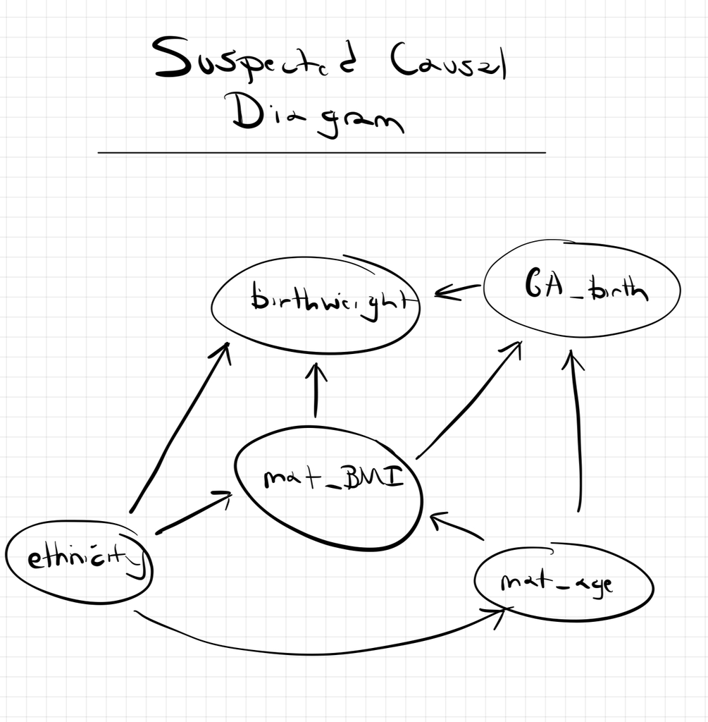

```r
knitr::include_graphics("causal_diagram.jpeg")
```

#### No Adjustments

```r
birthWeight_non_adjustment_model <- lm(birthWeight ~ mat_BMI, data = bw)
summary(birthWeight_non_adjustment_model)
```

```
##
## Call:
## lm(formula = birthWeight ~ mat_BMI, data = bw)
##
## Residuals:
##      Min       1Q   Median       3Q      Max
## -1030.54  -268.16   -37.09   257.02  1403.63
##
## Coefficients:
##             Estimate Std. Error t value Pr(>|t|)
## (Intercept) 2882.709     70.654  40.801  < 2e-16 ***
## mat_BMI       16.621      2.506   6.631 8.13e-11 ***
## ---
## Signif. codes:  0 '***' 0.001 '**' 0.01 '*' 0.05 '.' 0.1 ' ' 1
##
## Residual standard error: 393.4 on 537 degrees of freedom
## Multiple R-squared:  0.07569,    Adjusted R-squared:  0.07397
## F-statistic: 43.97 on 1 and 537 DF,  p-value: 8.128e-11
```

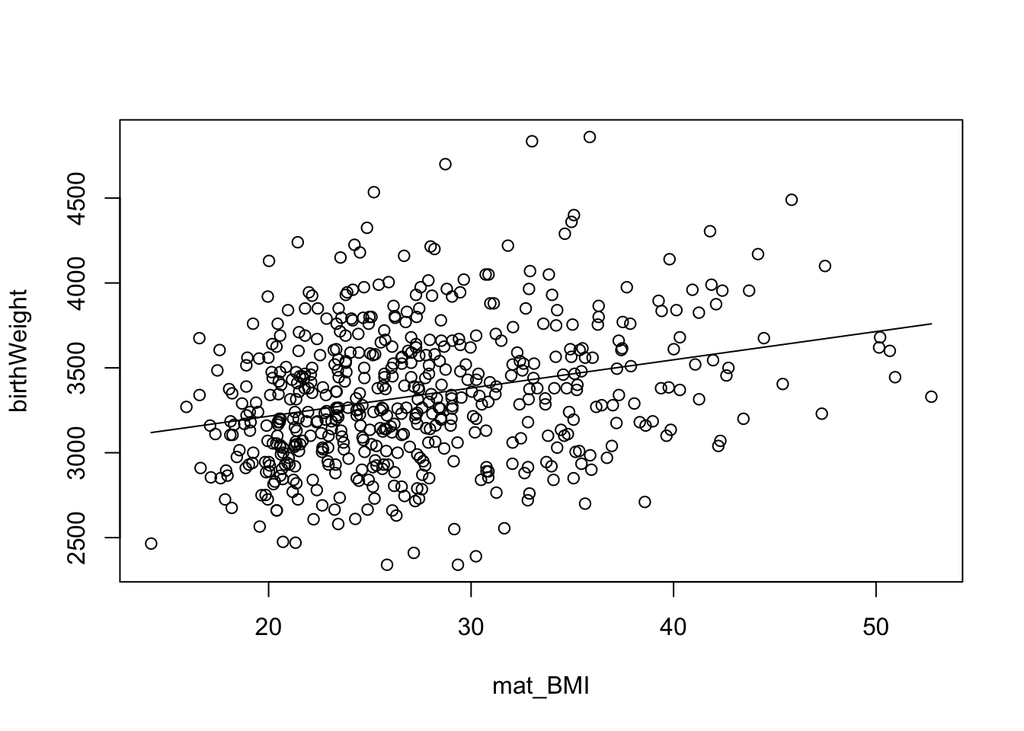

```r
xx <- seq(min(bw$mat_BMI), max(bw$mat_BMI), length.out = 100)
yy <- predict(birthWeight_non_adjustment_model, newdata = data.frame(mat_BMI = xx), type = 'response')
{
plot(birthWeight ~ mat_BMI, data = bw)
lines(yy ~ xx)
}
```

- For each unit increase of maternal BMI, there is an increase of 16.6g of baby birth weight. The estimated difference in birth weight associated with a change in BMI from 25 to 30, is 83.1g.
- Model appears to fit okay however there are possibly other confounders to include.

#### Adjusting for maternal ethnicity

```r
birthWeight_ethnicity_model <- lm(birthWeight ~ mat_BMI + ethnicity, data = bw)
summary(birthWeight_ethnicity_model)
```

```
##
## Call:
## lm(formula = birthWeight ~ mat_BMI + ethnicity, data = bw)
##
## Residuals:
##      Min       1Q   Median       3Q      Max
## -1073.43  -262.72   -24.53   260.04  1395.75
##
## Coefficients:
##                         Estimate Std. Error t value Pr(>|t|)
## (Intercept)              2893.45      77.91  37.137  < 2e-16 ***
## mat_BMI                    13.04       2.79   4.673 3.77e-06 ***
## ethnicityEuropean/other   235.80      60.47   3.899 0.000109 ***
## ethnicityIndian           -27.54      58.38  -0.472 0.637336
## ethnicityMaori             63.41      68.36   0.928 0.354066
## ethnicityPasifika         115.49      59.66   1.936 0.053408 .
## ---
## Signif. codes:  0 '***' 0.001 '**' 0.01 '*' 0.05 '.' 0.1 ' ' 1
##
## Residual standard error: 384.3 on 533 degrees of freedom
## Multiple R-squared:  0.1243, Adjusted R-squared:  0.1161
## F-statistic: 15.13 on 5 and 533 DF,  p-value: 6.567e-14
```

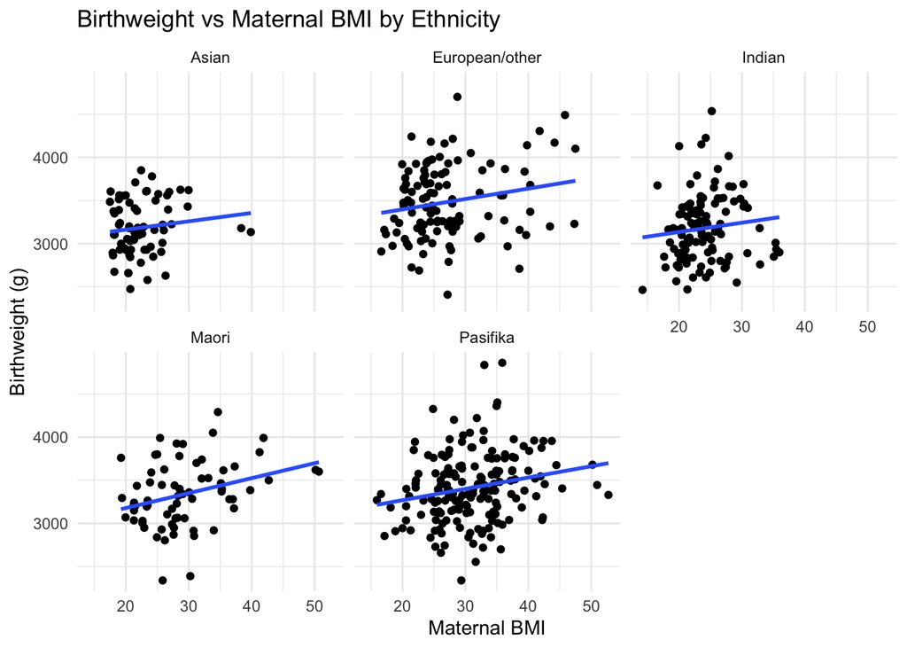

```r
ggplot(bw, aes(x = mat_BMI, y = birthWeight)) +
  geom_point() +
  geom_smooth(method = "lm", se = FALSE) +
  facet_wrap(~ ethnicity) +
  labs(title = "Birthweight vs Maternal BMI by Ethnicity",
       x = "Maternal BMI",
       y = "Birthweight (g)") +
  theme_minimal()
```

- The pivot ethnicity class is taken as Asian.
- Maternal ethnicity as European results in an increase of 236g of baby birth weight compared to Asian.
- Material ethnicity as Indian results in a decrease of 28g of baby birth weight compared to Asian (East Asian?).
- A decrease (change) in maternal BMI coefficient shows when we adjusted for ethnicity in our model, this means that there is an added effect of adjusting for ethnicity.
- This could mean that ethnicity is a confounder to maternal BMI and baby birth weight.
- The estimated difference in birth weight associated with a change in BMI from 25 to 30, is 65.2g.

#### Adjusting for maternal ethnicity and maternal age

```r
birthWeight_ethnicity_mat_age_model <- lm(birthWeight ~ mat_BMI + ethnicity + mat_age_deliv, data = bw)
summary(birthWeight_ethnicity_mat_age_model)
```

```
##
## Call:
## lm(formula = birthWeight ~ mat_BMI + ethnicity + mat_age_deliv,
##     data = bw)
##
## Residuals:
##     Min      1Q  Median      3Q     Max
## -1065.8  -262.6   -29.3   253.2  1383.4
##
## Coefficients:
##                         Estimate Std. Error t value Pr(>|t|)
## (Intercept)             2960.080    125.947  23.503  < 2e-16 ***
## mat_BMI                   13.150      2.796   4.703 3.28e-06 ***
## ethnicityEuropean/other  232.790     60.666   3.837 0.000139 ***
## ethnicityIndian          -29.589     58.493  -0.506 0.613172
## ethnicityMaori            47.561     72.333   0.658 0.511121
## ethnicityPasifika        103.472     62.301   1.661 0.097334 .
## mat_age_deliv             -2.411      3.579  -0.674 0.500867
## ---
## Signif. codes:  0 '***' 0.001 '**' 0.01 '*' 0.05 '.' 0.1 ' ' 1
##
## Residual standard error: 384.5 on 532 degrees of freedom
## Multiple R-squared:  0.125,  Adjusted R-squared:  0.1152
## F-statistic: 12.67 on 6 and 532 DF,  p-value: 2.195e-13
```

- Coefficients for material BMI do not change much from the simpler model with just the maternal ethnicity adjustment when we add in maternal age. This could mean that the effect of age is explained by ethnicity, or age has no added effect on other covariates.
- For every increase in maternal age at delivery, there is a 2.4g decrease in baby birth weight. The estimated difference in birth weight associated with a change in BMI from 25 to 30, is 65.8g.

#### Adjusting for all a priori suspected confounders (maternal age, ethnicity, and gestational age at birth)

```r
birthWeight_ethnicity_mat_age_GA_birth_model <- lm(birthWeight ~ mat_BMI + ethnicity + mat_age_deliv + GA_birth, data = bw)
summary(birthWeight_ethnicity_mat_age_GA_birth_model)
```

```
##
## Call:
## lm(formula = birthWeight ~ mat_BMI + ethnicity + mat_age_deliv +
##     GA_birth, data = bw)
##
## Residuals:
##     Min      1Q  Median      3Q     Max
## -957.31 -238.76  -24.78  219.44 1389.77
##
## Coefficients:
##                          Estimate Std. Error t value Pr(>|t|)
## (Intercept)             -2719.166    674.259  -4.033 6.32e-05 ***
## mat_BMI                    14.249      2.627   5.424 8.86e-08 ***
## ethnicityEuropean/other   195.458     57.094   3.423 0.000666 ***
## ethnicityIndian           -23.962     54.891  -0.437 0.662629
## ethnicityMaori             46.909     67.874   0.691 0.489798
## ethnicityPasifika          73.196     58.567   1.250 0.211932
## mat_age_deliv              -4.167      3.365  -1.238 0.216086
## GA_birth                  144.949     16.942   8.555  < 2e-16 ***
## ---
## Signif. codes:  0 '***' 0.001 '**' 0.01 '*' 0.05 '.' 0.1 ' ' 1
##
## Residual standard error: 360.8 on 531 degrees of freedom
## Multiple R-squared:  0.231,  Adjusted R-squared:  0.2209
## F-statistic: 22.79 on 7 and 531 DF,  p-value: < 2.2e-16
```

### Q2)

- You can’t. In order for a covariate to be a confounder to another covariate, cause needs to proceed effect. In this case, the gestational age at birth does not proceed the maternal BMI.